# ENV H 570: Lab 4

Joan A. Casey

26 March, 2025

## Objective

The goal of this lab is to work with various spatial data sources and explore different ways to map and visualize them. We will work with some data from Seattle on SES, income, and housing vacancy, in addition to noise data from two different sources – the data that we collected as a class and data from a national noise model. We will explore different ways of combining and displaying these data.

## Setup

```r
# Clear workspace of all objects and unload all extra (non-base) packages.
rm(list = ls(all = TRUE))
if (!is.null(sessionInfo()$otherPkgs)) {
  res <- suppressWarnings(
    lapply(paste('package:', names(sessionInfo()$otherPkgs), sep=""),
           detach, character.only=TRUE, unload=TRUE, force=TRUE))
}

# Load packages, installing if needed
if (!requireNamespace("pacman", quietly = TRUE)){
  install.packages("pacman")}
pacman::p_load(
  conflicted,
  here,
  dplyr,
  tidyr,
  sf,
  ggplot2,
  MetBrewer,
  RColorBrewer,
  patchwork,
  readr,
  leaflet,
  leaflegend,
  ggmap,
  raster
)

# NOTE: We will use the terra package below, and it is automatically loaded with
# `raster`. If you load it separately, it causes some conflicts and issues, so
# we load it via `raster`. But, since we use it below, we wanted to flag this!
```

## Load and clean data

### Seattle SES and tree coverage data

What projection are these data in? Let’s also visualize them to get a sense of what is there!

```r
seattle <- st_read(here("data/lab/04/seattle_tree_ses_ct.shp"))
dplyr::glimpse(seattle)
```

```
## Rows: 133
## Columns: 6
## $ GEOID10  <chr> "53033000800", "53033000700", "53033000600", "53033000500", "…
## $ tr_dnst  <dbl> 18801.055, 14909.070, 12765.697, 23602.818, 11270.662, 11295.…
## $ TOTAL_P  <dbl> 2582, 4854, 8061, 3052, 5300, 6721, 2822, 7973, 7963, 4236, 4…
## $ PCT_VAC  <dbl> 5.4, 7.8, 6.1, 10.3, 2.6, 6.4, 2.1, 5.1, 6.2, 5.6, 3.0, 11.6,…
## $ MEDIAN_  <dbl> 97344, 52957, 61536, 135524, 64972, 32568, 73098, 67397, 5003…
## $ geometry <POLYGON [US_survey_foot]> POLYGON ((1281530 265054.8,..., POLYGON …
```

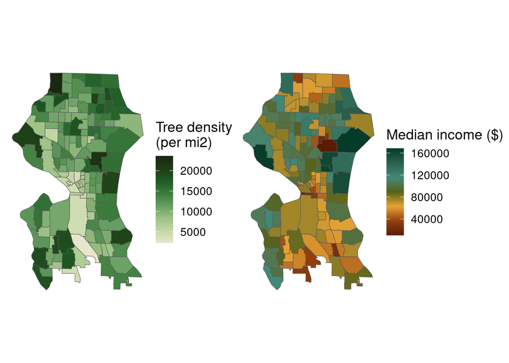

```r
# Plot tree density
tree_density <- ggplot() +
  geom_sf(data = seattle, aes(fill = tr_dnst)) +
  theme_void(base_size = 14) +
  theme(
    axis.text.x = element_blank(),
    axis.text.y = element_blank(),
    axis.ticks = element_blank(),
    rect = element_blank()
  ) +
  scale_fill_gradientn("Tree density \n(per mi2)",
                       colors = met.brewer("VanGogh3"),
                       na.value = "grey50")


# Plot median income
income <- ggplot() +
  geom_sf(data = seattle, aes(fill = MEDIAN_)) +
  theme_void(base_size = 14) +
  theme(
    axis.text.x = element_blank(),
    axis.text.y = element_blank(),
    axis.ticks = element_blank(),
    rect = element_blank()
  ) + scale_fill_gradientn("Median income ($)",
                           colors = met.brewer("Degas"),
                           na.value = "grey50")

#Plotting these side-by-side using patchwork
tree_density + income
```

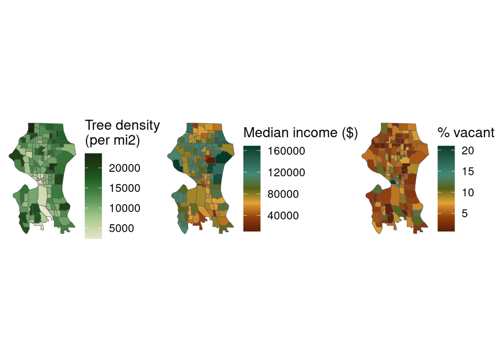

```r
# Try adding figure for percent vacant housing below
vacant <- ggplot() +
  geom_sf(data = seattle, aes(fill = PCT_VAC)) +
  theme_void(base_size = 14) +
  theme(
    axis.text.x = element_blank(),
    axis.text.y = element_blank(),
    axis.ticks = element_blank(),
    rect = element_blank()
  ) + scale_fill_gradientn("% vacant",
                           colors = met.brewer("Degas"),
                           na.value = "grey50")

#Plotting these side-by-side using patchwork
tree_density + income + vacant
```

Do you notice any issues with the color palette here? Let’s try again with a better color palette for percent vacant homes.

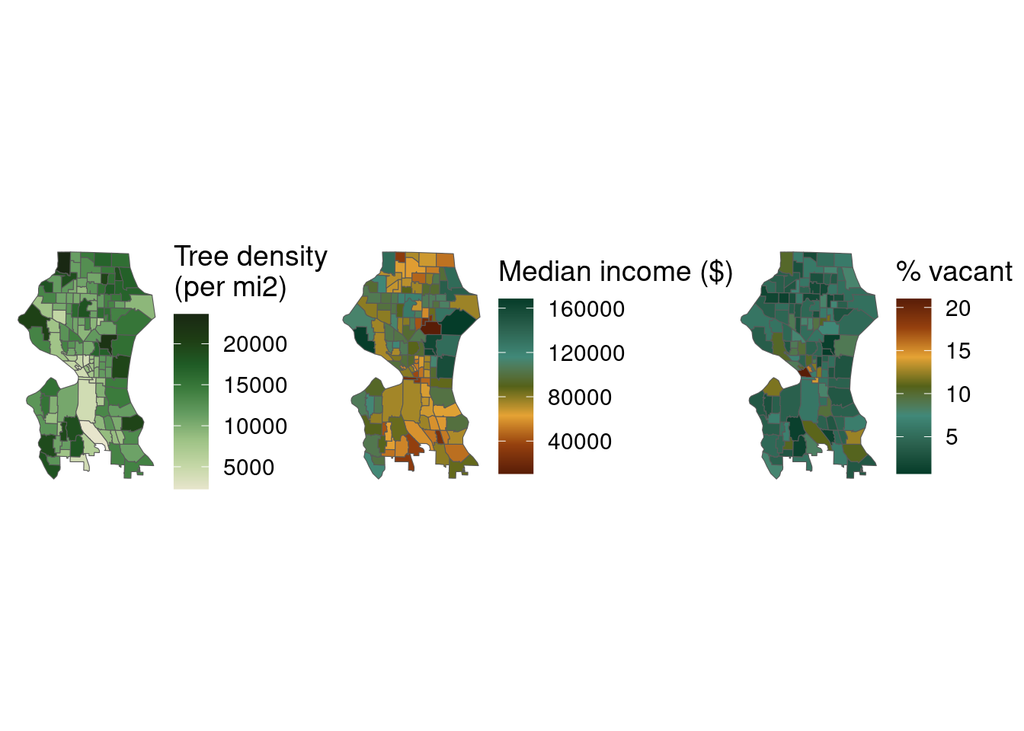

```r
flipped_palette <- rev(met.brewer("Degas"))
vacant <- ggplot() +
  geom_sf(data = seattle, aes(fill = PCT_VAC)) +
  theme_void(base_size = 14) +
  theme(
    axis.text.x = element_blank(),
    axis.text.y = element_blank(),
    axis.ticks = element_blank(),
    rect = element_blank()
  ) + scale_fill_gradientn("% vacant",
                           colors = flipped_palette,
                           na.value = "grey50")
tree_density + income + vacant
```